# Bubble Sort

*(Open .GIF below in new tab to run)*

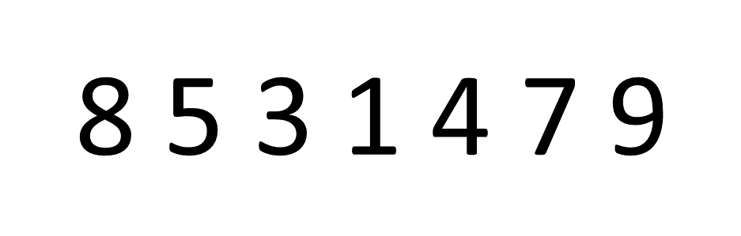

Ý tưởng:

- Ta lặp qua từng phần tử một
  - Tại một phần tử
    - Ta lặp qua các phần tử còn lại
      - Nếu phần tử nào trong các phần tử còn lại mà nhỏ hơn phần tử hiện tại thì thay thế phần tử hiện tại bằng phần tử nhỏ hơn đó

```python
lst = [6, 8, 12, 5, 1.5, 0.25, 58, 15, 100]
```

```python
for i in range(0, len(lst)):
    for j in range (i + 1, len(lst)):
        if lst[j] < lst[i]:
            temp = lst[i]
            lst[i] = lst[j]
            lst[j] = temp
```

```python
lst
```

```
[0.25, 1.5, 5, 6, 8, 12, 15, 58, 100]
```

Độ phức tạp: **O(N^2)**

# Insertion Sort

*(Open .GIF below in new tab to run)*

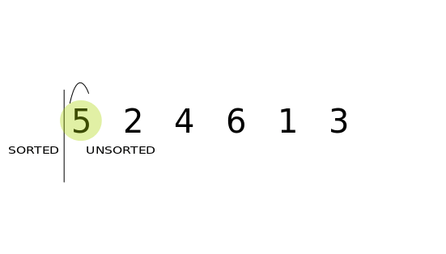

Ý tưởng:

- Ta lặp qua từng phần tử một:
  - Tại một phần tử
    - Ta lặp qua các phần tử ở trước phần tử này:
      - Tìm vị trí mà phần tử này lớn hơn các phần tử bên trên và nhỏ hơn các phần tử bên phải
      - Di chuyển tất cả các phần tử bên phải lên một bậc
      - Đặt phần tử này vào vị trí đó (Đây chính là ý nghĩa Insertion(chèn))

```python
lst = [6, 8, 12, 5, 1.5, 0.25, 58, 15, 100]
lst
```

```
[6, 8, 12, 5, 1.5, 0.25, 58, 15, 100]
```

```python
for i in range(1, len(lst)):
    j = i - 1
    current = lst[i]
    while j >= 0 and current < lst[j]:
        lst[j + 1] = lst[j]
        j -= 1
    lst[j+1] = current
```

```python
lst
```

```
[0.25, 1.5, 5, 6, 8, 12, 15, 58, 100]
```

Độ phức tạp: **O(N^2)**

# Merge Sort

Merge sort sử dụng giải thuật **divide and conquer**

*(Open .GIF below in new tab to run)*

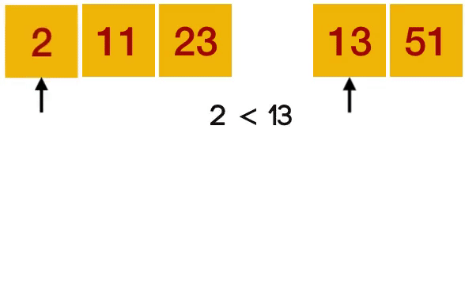

```python
lst = [6, 8, 12, 5, 1.5, 0.25, 58, 15, 100]
lst
```

```
[6, 8, 12, 5, 1.5, 0.25, 58, 15, 100]
```

```python
# Divide
def divide(numbers, start, end):
    if start == end:
        return [numbers[start]]
    else:
        middle = (start + end) // 2
        left_numbers = divide(numbers, start, middle)
        right_numbers = divide(numbers, middle+1, end)
        return conquer(numbers, left_numbers, right_numbers)
```

```python
# Sort
def conquer(numbers, left_numbers, right_numbers):
    new_nums = []
    i = 0
    j = 0
    while i < len(left_numbers) and j < len(right_numbers):
        if left_numbers[i] < right_numbers[j]:
            new_nums.append(left_numbers[i])
            i += 1
        else:
            new_nums.append(right_numbers[j])
            j += 1
    if i < len(left_numbers):
        new_nums += left_numbers[i:]

    if j < len(right_numbers):
        new_nums += right_numbers[j:]
    return new_nums
```

```python
divide(lst, 0, len(lst) - 1)
```

```
[0.25, 1.5, 5, 6, 8, 12, 15, 58, 100]
```

Độ phức tạp: **O(Nlog(N))**

# np.sort( a, axis = -1, kind = None, order = None )

**a** : array_like Array to be sorted.

**axis** : int or None, optional *(The default is -1)* Axis along which to sort. If None, the array is flattened before sorting. The default is -1, which sorts along the last axis.

**kind** : {'quicksort', 'mergesort', 'heapsort', 'stable'}, optional *(The default is 'quicksort')*

**order** : str or list of str, optional

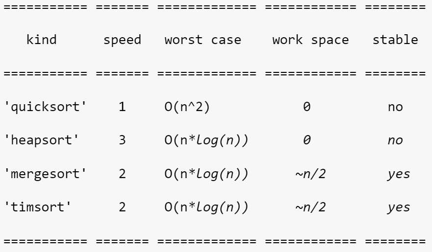

```python
import numpy as np
```

```python
lst = [6, 8, 12, 5, 1.5, 0.25, 58, 15, 100]
lst
```

```
[6, 8, 12, 5, 1.5, 0.25, 58, 15, 100]
```

```python
lst = list(np.sort(lst, kind = 'mergesort'))
```

```python
lst
```

```
[0.25, 1.5, 5.0, 6.0, 8.0, 12.0, 15.0, 58.0, 100.0]
```

# lst.sort( *, key = None, reverse = False )

```python
lst = [6, 8, 12, 5, 1.5, 0.25, 58, 15, 100]
lst
```

```
[6, 8, 12, 5, 1.5, 0.25, 58, 15, 100]
```

```python
lst.sort()
lst
```

```
[0.25, 1.5, 5, 6, 8, 12, 15, 58, 100]
```

```python
lst.sort(reverse = True)
lst
```

```
[100, 58, 15, 12, 8, 6, 5, 1.5, 0.25]
```

# arr.sort( axis = -1, kind = None, order = None )

**axis** : int, optional Default is -1

**kind** : {'quicksort', 'mergesort', 'heapsort', 'stable'}, optional The default is 'quicksort'.

**order** : str or list of str, optional

```python
arr = np.array([[1,5,9,10,2,3], [9,3,8,4,6,100]])
arr
```

```
array([[  1,   5,   9,  10,   2,   3],
       [  9,   3,   8,   4,   6, 100]])
```

```python
arr.sort()
arr
```

```
array([[  1,   2,   3,   5,   9,  10],
       [  3,   4,   6,   8,   9, 100]])
```